# Question

Consider the quadratic function graphed below:

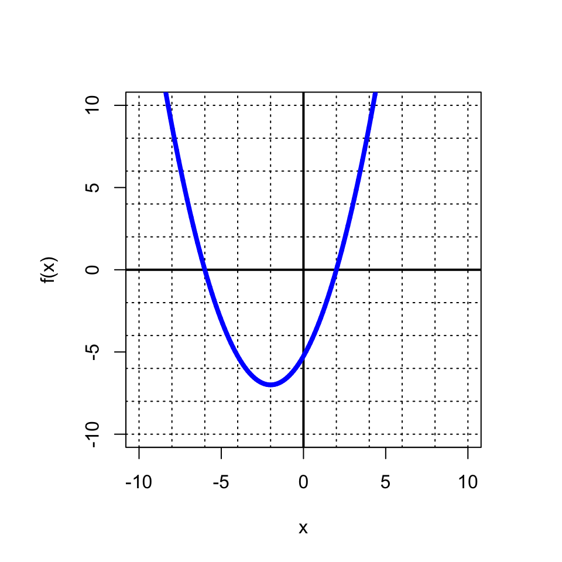

- What is the interval(s) over which the function is positive? ##ANSWER1##
- What is the interval(s) over which the function is negative? ##ANSWER2##
- What is the interval(s) over which the function is increasing? ##ANSWER3##
- What is the interval(s) over which the function is decreasing? ##ANSWER4##
- What is the domain (in interval notation)? ##ANSWER5##
- What is the range (in interval notation)? ##ANSWER6##

## Answerlist

- (-∞,-2)
- (-6,2)
- [-7,∞)
- (-2,∞)
- (-∞,-6)U(2,∞)
- (-∞,∞)
- (-∞,-2)
- (-6,2)
- [-7,∞)
- (-2,∞)
- (-∞,-6)U(2,∞)
- (-∞,∞)
- (-∞,-2)
- (-6,2)
- [-7,∞)
- (-2,∞)
- (-∞,-6)U(2,∞)
- (-∞,∞)
- (-∞,-2)
- (-6,2)
- [-7,∞)
- (-2,∞)
- (-∞,-6)U(2,∞)
- (-∞,∞)
- (-∞,-2)
- (-6,2)
- [-7,∞)
- (-2,∞)
- (-∞,-6)U(2,∞)
- (-∞,∞)
- (-∞,-2)
- (-6,2)
- [-7,∞)
- (-2,∞)
- (-∞,-6)U(2,∞)
- (-∞,∞)

# Solution

- Positive: (-∞,-6)U(2,∞)
- Negative: (-6,2)
- Increasing: (-2,∞)
- Decreasing: (-∞,-2)
- Domain: (-∞,∞)
- Range: [-7,∞)
- The function “is positive” when $f(x)>0$. The interval refers to the $x$ values (inputs) that produce a positive output. Determine where the curve is above the $x$ axis. Indicate “where” with the $x$ values at the endpoints: (-∞,-6)U(2,∞)
- The function “is negative” when $f(x)<0$. The interval refers to the $x$ values (inputs) that produce a negative output. Determine where the curve is below the $x$ axis. Indicate “where” with the $x$ values at the endpoints: (-6,2)
- The function is increasing when an ant going left-to-right is walking up hill: (-2,∞)
- The function is decreasing when an ant going left-to-right is walking down hill: (-∞,-2)

# Meta-information

extype: cloze exclozetype: schoice|schoice|schoice|schoice|schoice|schoice exsolution: 000010|010000|000100|100000|000001|001000 exname: intervals_quadratic exshuffle: false